# Investigating the role of iconicity in the transmission of sensory vocabulary in Japonic

# Background

Research has shown that iconicity aids language learning and processing. Our question is whether or not this also results in a transmission bias for iconicity over time?

To answer this question, we examine the transmission of **sensory vocabulary** in the Japonic language family. We focus on sensory vocabulary as this is a domain where iconicity is very concentrated.

Japonic was used as it has a distinct lexical stratum of iconic words, ideophones, which exists in parallel to the ‘prosaic’ (non-ideophone) stratum. Some concepts have both a prosaic and an ideophonic equivalent (see examples in the figure below). Since different concepts evolve at different rates, these doubly represented concepts provide a unique opportunity to examine the effect of iconicity on the transmission of sensory vocabulary, while controlling (to a certain extent) for the concept itself.

## Data

Data was compiled from three sources: Hirayama (1992), Sanada & Tomosada (2015), and Sanada & Tomosada (2018). The items in each source were elicited from participants in different parts of Japan by asking a representative speaker (only one per location sadly) to translate a Standard Japanese exemplar sentence illustrating a concept into their local variety. Sometimes, these exemplar sentences contained both ideophones and prosaic words illustrating the same concept. This is shown in exemplar sentence (1) in the figure below.

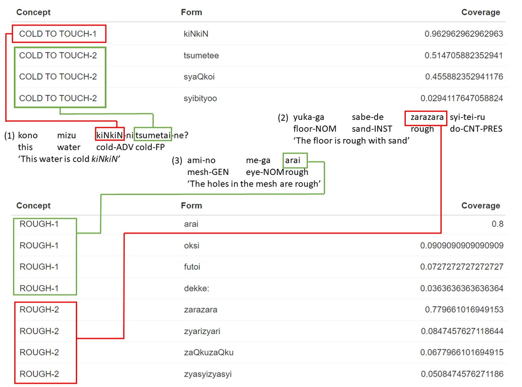

The data for COLD TO TOUCH-1 comes from translations of *kiNkiN*, while the data for COLD TO TOUCH-2 comes from translations of *tsumetai*. Participants tended to translate ideophones with other ideophones, and prosaic words with other prosaic words, but there were also cases where a prosaic word was translated with an ideophone, or vice-versa.

In the case of *kiNkiN* and *tsumetai* the doubly represented concepts come from the same exemplar sentence, but there are also examples where the same concept was elicited in different exemplar sentences. This is shown in exemplar sentences (2) and (3) above, from which I collected data for the concepts ROUGH-1 and ROUGH-2.

Altogether there are 17 doubly (or sometimes triply) represented concepts in the data, shown in the table below. Ideophones (in the Standard Japanese exemplar sentence) are shown in bold.

| Concept | Japanese | Exemplar |
| --- | --- | --- |
| ANNOYED/IMPATIENT-1 | iraira | My turn in the line still wouldn't come, and I was getting ANNOYED/IMPATIENT. |
| ANNOYED/IMPATIENT-2 | zyireQtai | No matter how many times I wrote it, I couldn't get it right and I was getting ANNOYED/IMPATIENT. |
| ANNOYED/IMPATIENT-3 | modokasyii | That guy is always so slow at work, it's ANNOYING/makes me IMPATIENT. |
| ROUGH-1 | arai | The holes in the mesh are ROUGH. |
| ROUGH-2 | zarazara | The floor is ROUGH with sand. |
| COLD TO TOUCH-1 | kiNkiN | This water is COLD. |
| COLD TO TOUCH-2 | tsumetai | This water is COLD. |
| EXHAUSTED-1 | guQtari | Because I've been working in the field all day, I'm completely exhausted. |
| EXHAUSTED-2 | syiNdoi | (After working in the heat), Aaa, I'm EXHAUSTED. |
| HUMID-1 | musyimusyi | Today is really HUMID. Because it's so HUMID please turn on the air con. |

[output cut: 26 more lines]

Not all of them are doubly represented by an ideophone and a prosaic word, some were doubly represented by different prosaic words (in the exemplar sentence), while others were doubly represented by different ideophones. However, we expect there to be variation in iconicity both within and across the categories of ‘prosaic words’ versus ‘ideophones’, so I think these will still be interesting to compare.

After the 17 doubly(/triply) represented concepts, there are 74 singleton concepts, stretching across 10 semantic domains. The complete list is shown below (again with the ideophones in bold):

| Concept | Japanese | Exemplar | Freq per million | Data source | Semantic domain | No. cognate classes |
| --- | --- | --- | --- | --- | --- | --- |
| A LITTLE | sukosyi | It's raining A LITTLE. | 415.948 | hirayama_1992 | action | 5 |
| BIND | syibaru | BIND a leg | 15.426 | hirayama_1992 | action | 5 |
| BLOW | fuku | To BLOW on a flame. | 35.003 | hirayama_1992 | action | 1 |
| CHEW | kamu | Eat it and CHEW it well! | 32.012 | hirayama_1992 | action | 3 |
| CLINGING | netyinetyi | Because they CLING to their grudges, you need to be careful around that person. | 1.483 | sanada_2015 | action | 1 |
| CRAWL | hau | the child CRAWLS | 6.845 | hirayama_1992 | action | 4 |
| CUNNING | zurui | But they didn't look like a CUNNING person at all. | 5.585 | sanada_2015 | action | 15 |
| FAST | hayai | Walking FAST | 18.152 | hirayama_1992 | action | 1 |
| OOZING | zyikuzyiku | (When the inside of your ear is swollen and pus is coming out) The back of my ear is OOZING (pus). | 0.329 | sanada_2018 | action | 7 |
| ROLL | mawaru | Wheels ROLL. | 96.544 | hirayama_1992 | action | 2 |

[output cut: 100 more lines]

The frequency per million data comes from the frequency of the **Standard Japanese word used in the exemplar sentence** in the [JaTenTen corpus](https://www.sketchengine.eu/jatenten-japanese-corpus/), a Japanese web corpus. I am planning to include this as a factor in the analyses, since ideophones generally have a much lower frequency (even when representing the same concept) than prosaic words, and frequency of use also affects rates of evolution (Pagel, Atkinson, and Meade 2007).

Ideophones tend to be used less frequently because they are a more marked/dramatic way of saying something that could be said more neutrally using prosaic words (although there are also concepts which can only be expressed using ideophones; for example the prosaic pain lexicon is very limited when compared to the ideophonic pain lexicon, which you can see if you filter the table above by the semantic domain ‘pain’).

## Locations/Variation in Japan

Translations of the exemplar sentences for each concept were collected from speakers in 49 locations across Japan, shown below:

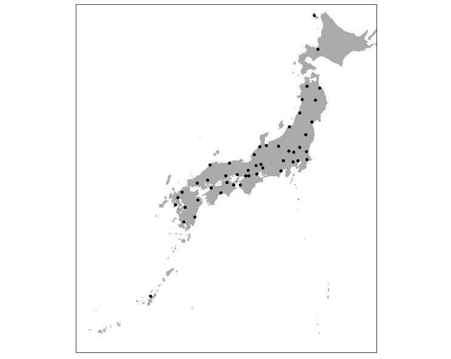

Sadly there is only one location in the Ryukyus, were the most variation is, but there is also a lot of variation in Kyushu (in the south) and Tohoku (in the north), and we have a lot of data points in these locations. The variation within Japonic is roughly comparable to a language family like Germanic, and they are similar in age as well.

## Distribution of Cognate Classes

The histogram below shows the numbers of cognate classes found across the 49 locations for all the concepts in the data, which ranges from 1 (e.g. CLINGING, BRIGHT) to 24 (EXHAUSTED-2). I noticed negatively valenced concepts often seem to have more cognate classes (there is something written about this in Dutch dialects too).

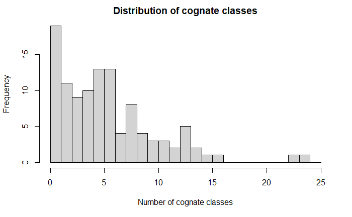

## Independence of cognate classes

We checked for independence of cognate classes (within a concept) by comparing the PMI (pointwise mutual information) between concepts versus within the same concept for all the cognate classes in the data.

The graph below shows the distribution of the z scores for the PMI within versus between concepts.

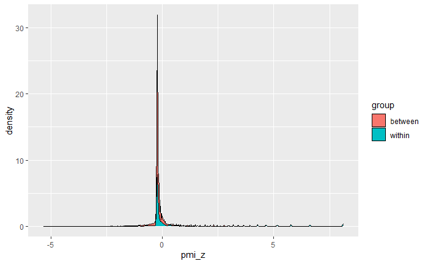

The two distributions are 7.041574210^{-4} z-scores apart, so less than a standard deviation which should mean the cognate classes are independent of each other.

# Iconicity measures

We cannot do any meaningful analysis without a reliable measure of the iconicity of these forms. Currently, we are using two measures of iconicity for the data:

1. Iconicity ratings
2. Guessability scores

Both of these come from naieve, monolingual English-speaking participants recruited through the crowdsourcing website [Prolific](https://www.prolific.co/).

In the rating task, participants are asked to rate how well they think the word and its meaning ‘fit with’ one another on a scale from 0 (‘no resemblance’) to 6 (‘strong resemblance’) between the word and its meaning. You can see a full demo [here](https://bonniemclean.github.io/experiment3-ratings#).

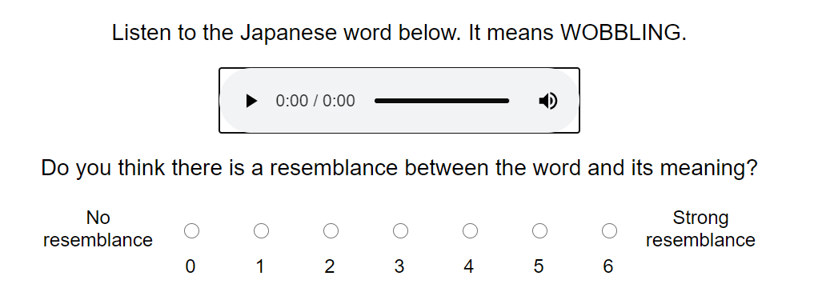

In the guessing task, participants are asked to match the translation provided to the correct Japanese word, choosing between the correct word and a pseudoword created by substituting each phoneme in the correct word with its ‘opposite phoneme’ using phonological edit distances informed by a feature matrix. An example is shown below, with *yoroyoro* as the real word and *seke* as the opposite word (When making the opposite words, we also got rid of any expressive morphology, including unreduplicating reduplicated forms). A full demo is [here](https://bonniemclean.github.io/experiment3-guessing#).

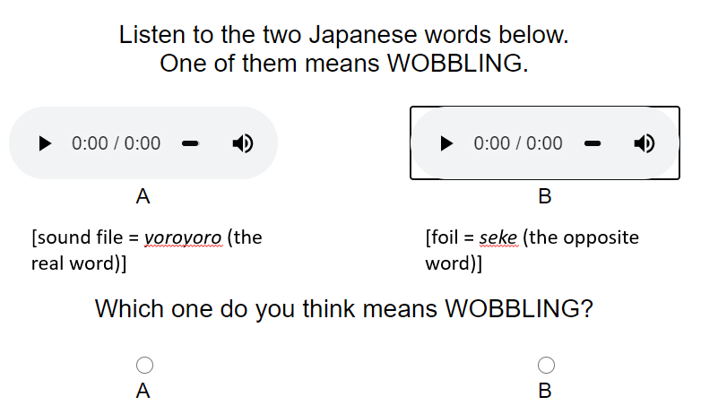

The logic behind this is that if the form of the real word is a good fit for that meaning, participants should choose the real word more often, while its ‘opposite’ word should be an inapproporiate fit for that meaning.

It is a bit different to the way iconicity guessing experiments have been run in the past. In previous studies, participants usually match the word to the translation (choosing from two translations), rather than matching the translation to the word (choosing from two words). We piloted studies like this, but found that the results were highly influenced by which words were used as the foil translations in ways that were difficult to untangle. I think using less of the native language of participants (i.e. English) is better, because there are too many things that they know about the native language that influence their responses. And doing it this way also made it more comparable to the rating study, where they are also only given a single English translation.

The graph below shows the correlation between the ratings and the guesses, where the ratings have been converted into a percentage by dividing the mean rating for the word by 7 (since it was a 7-point scale). Ideophones are shown in blue and non-ideophones in red.

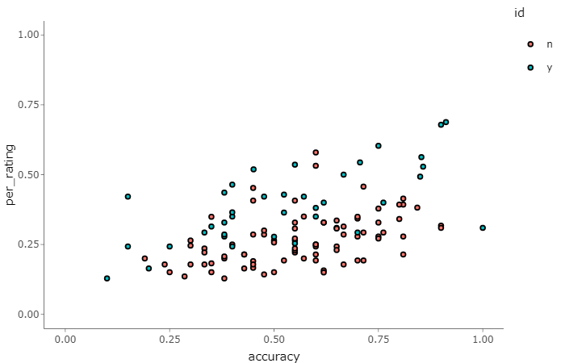

You can see there is definitely a correlation so the measures seem to make sense. Outliers in the top left indicate something fishy going on with the guessing studies (they are not guessed as well as we would expect them to be based on their rating), while outliers in the bottom right indicate something fishy going on with the ratings (words were not rated as very iconic, and yet they were guessed very well).

There are more outliers for the ratings than the guesses. Particularly, we found that raters often 'miss' iconicity in prosaic words. That is, they rate them as not very iconic, but then when we do the guessing studies we find these words guessed at very high accuracies. An example of this was *futoi* 'thick'. Also, raters tend to rate ideophones as more iconic than non-ideophones, even when these are guessed at the same accuracy. I think this is because the ideophones are reduplicated, and iconic words in English (and cross-linguistically) are often reduplicated as well. So participants may be biased to rate these words as more iconic, compared to non-ideophones/prosaic words. However, from the guessing studies we can see that even when the iconicity of a prosaic words is not obvious to participants (from the rating results), it can still help them to guess the word correctly.

Because of this bias in the ratings results, we are thinking of using just the guessing results as the iconicity measures for the words. But it is good to have the ratings as an extra check that the guessing results make sense. The guessing results also give a larger spread of iconicity scores/bigger differences between the words, which will be more helpful for our analyses when we combine this data with information about the vertical stability of these words.

## Which words?

Since we can’t collect an iconicity measure for all the words (we don’t have endless amounts of time/money), for each cognate class in each concept, we take the most common form for that cognate class and collect an iconicity measure for that form (with the relevant meaning).

The only exception is that we don’t collect iconicity measures for cognate classes that are only used in a single variety in the data, since we cannot really say anything about the transmissability of these forms.

In some cases, I decided to collect an iconicity measure for multiple popular competing versions of one cognate class, if it seems like maybe there might be a difference in iconicity between them. For example, *kosui* ‘SLY/CUNNING’ has metathesised to *sukoi* or *sukkoi* (with a geminate) in a lot of varieties. It would be interesting if *sukoi* and especially *sukkoi* (there is even a *zukkoi* in some parts) are more iconic, and if this potentially helped their spread.

The forms tested for each concept, along with their coverage (as the percentage of forms for that concept which belong to that cognate class), are shown below:

```
There were 45 warnings (use warnings() to see them)
```

| Concept | Form | Coverage |
| --- | --- | --- |
| (SPINE) TINGLING | zokuzoku | 0.576923076923077 |
| (SPINE) TINGLING | biQto | 0.173076923076923 |
| (SPINE) TINGLING | zawazawa | 0.0961538461538462 |
| (SPINE) TINGLING | zomizomi | 0.0384615384615385 |
| A LITTLE | nigai | 0.666666666666667 |
| A LITTLE | tyobiQto | 0.155555555555556 |
| A LITTLE | sukosyi | 0.155555555555556 |
| ACRID (TASTE) | egui | 0.924528301886792 |
| ACRID (TASTE) | egunigai | 0.0377358490566038 |
| ANNOYED/IMPATIENT-1 | iraira | 0.684210526315789 |

[output cut: 324 more lines]

# Analysis goals

## Immediate goals

Since we are collecting iconicity measures for each cognate set within the concepts, we would like a measure of the rate of replacement for each cognate set (not just for the concept as a whole). This is what draws me to the Dirichlet process mixture model (used in Greenhill et al. 2017) for inferring rates of change, because that allows you to infer rates for cognate sets within meaning categories. So please tell us if we can do this/tips on how to do this.

## Future goals

**1. More complex analyses**

- The rates analysis only tells us about the vertical stability of these forms. It would be nice to know about their horizontal diffusability as well, since iconicity could make a form more ‘borrowable’ too. (I am slightly worried about that being a problem when we make the trees, but I’m hoping this can be avoided by constraining the trees to fit with a tree made from basic vocabulary data that is less likely to be borrowed, using data from Lee & Hasegawa).
- One study I found which made a model separating vertical stability and horizontal diffusability is by Murawaki & Yamauchi (2018). Maybe we could contact them at some point and ask if they think this model would work with our data.

**2. Broadening the data**

- It would also be interesting to do this same study in another language family. I think Aslian would be interesting because it has languages with no ideophones, languages with ideophones, and languages with ideophones but they’re typologically different from ideophones in Japanese, so we could see how these factors influence transmissability.
- Related to this it would also be good to do the study in another semantic domain.
- Say we find iconicity is more transmissable in this data, then we need to ask what other contexts does this apply to, is it more transmissable because the domain is sensory vocabulary? Or because of how ideophones in Japanese work? Would it be equally transmissable in another semantic domain? Or in a language where ideophones are perhaps not as embedded into the rest of the grammar and lexicon as they are in Japanese? (e.g. Semai)

**3. Different methods**

- I had an idea with Mark before about some fun communication experiments we could do to explore more how iconicity might help with communicating about sensory experiences. In a post-covid world I could go to Nagoya and do this.

Ideas (1) and (3) might be good to combine because (3) I was planning to do in Nagoya, and Murawaki & Yamauchi are in Kyoto which is very close. (2) is probably the easiest thing to move on with while corona is still happening.

# Extra notes on ideophone typology

If you want more explanation about why the nature of ideophones in the language might influence their transmissability. We can imagine a continuum stretching from ‘regular words’ (which are very integrated, very conventionalised, and not obviously iconic) to ‘spontaneous gesture’ (which is not very integrated, not very conventionalised, but obviously iconic), with ideophones in different languages falling in between. Like in the figure below:

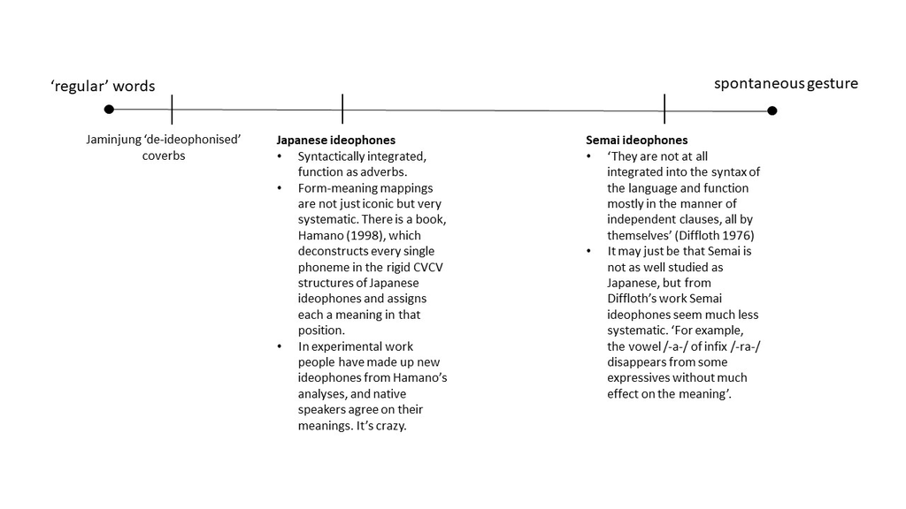

Experimental studies have shown that some degree of systematicity is also needed for linguistic items to be transmissable, and so in languages where ideophones may be highly iconic but not very systematic (e.g. closer to the spontaneous gesture end of the continuum) we may not see this same transmissability effect of iconicity.

I talk about this iconicity/systematicity trade-off in Japanese ideophones in my honours thesis, and I found that ideophones that combined the two (both iconicity and systematicity) were the most stable when it came to regular sound change.

# References

Greenhill, Simon J., Chieh-Hsi Wu, Xia Hua, Michael Dunn, Stephen C. Levinson, and Russell D. Gray. 2017. “Evolutionary Dynamics of Language Systems.” *Proceedings of the National Academy of Sciences* 114 (42): E8822–E8829.

Hirayama, Teruo. 1992. *Gendai Nihongo Hōgen Daijiten [Dictionary of Contemporary Japanese Dialects]*. Tokyo, Japan: Meiji-shoin.

Murawaki, Yugo, and Kenji Yamauchi. 2018. “A Statistical Model for the Joint Inference of Vertical Stability and Horizontal Diffusibility of Typological Features.” *Journal of Language Evolution* 3 (1): 13–25.

Pagel, Mark, Quentin D. Atkinson, and Andrew Meade. 2007. “Frequency of Word-Use Predicts Rates of Lexical Evolution Throughout Indo-European History.” *Nature* 449 (7163): 717–20.

Perlman, Marcus, and Gary Lupyan. 2018. “People Can Create Iconic Vocalizations to Communicate Various Meanings to Naïve Listeners.” *Scientific Reports* 8 (1): 1–14. https://doi.org/10.1038/s41598-018-20961-6.

Sanada, Shinji, and Kenji Tomosada, eds. 2015. *Kenbetsu Hoogen Kanzyoo Hyoogen Jiten [Dialect Dictionary of Emotion Expressions by Prefecture]*. Tokyo: Tokyodo.

———, eds. 2018. *Kenbetsu Hoogen Kankaku Hyoogen Jiten [Dialect Dictionary of Sensory Expressions by Prefecture]*. Tokyo: Tokyodo.